# ML2 Regression project - predicting car price in USD

Edyta Pszczółkowska 435022

19 02 2022

The aim of this project is to predict car’s price (in USD) using as independent variables the most basic traits and parameters. As the dataset was collected in 2019, the model will predict the prices as of 2019.

*Final variables after feature selection are:

- brand - categorical, 5 distinct values
- year - age of a car
- mileage in kilometers - continuous
- type of the fuel ( petrol, diesel) - binary
- volume of the engine in cm3 - continuous
- transmission (automate, manual) - binary
- drive unit - categorical, 5 distinct values

Source: https://www.kaggle.com/slavapasedko/belarus-used-cars-prices

The methods and algortihms will be: -linear regression -regression tree -random forest -gradient boost

Such a model can be helpful not only for car dealers or individuals who want to buy or sell a car, but also in a wide range of business sector, e.g. insurance companies, banks (car as a loan security), leasing companies or debt collectors.

```r
library(tree)
library(caret)
library(rpart)
library(rpart.plot)
library(rattle)
library(ggplot2)
library(dplyr)

source("getRegressionMetrics.R")
```

```r
setwd("D:\\Edyta pliki\\DS\\III semestr\\ML2")
cars <-  read.csv("cars.csv")
```

The dataset is really huge. Therefore I will keep 10% of it. To keep the same distribution of dependent variable as in the original dataset, I will choose the same function which is used to split data into train and test sample.

```r
set.seed(987654321)
which_to_take <- createDataPartition(y = cars$priceUSD,
                                   p = 0.1,
                                   list = FALSE)

cars <- cars[which_to_take,]
```

## EDA, feature selection

Checking NAs…

```r
cars[!complete.cases(cars), ]
```

```
##             make  model priceUSD year    condition mileage.kilometers.
## 2269  alfa-romeo    147     8097 2007 with mileage               700.0
## 29352        bmw     i3    22900 2015 with mileage             50000.0
## 32458     nissan   leaf    15649 2016 with mileage             15321.0
## 32463     nissan   leaf    12950 2013 with mileage             62000.0
## 39015 volkswagen passat     7499 2007 with mileage            530000.0
## 52647  chevrolet   volt    22000 2015 with mileage            157715.3
##        fuel_type volume.cm3.    color transmission        drive_unit segment
## 2269  electrocar         NaN burgundy    mechanics                         C
## 29352 electrocar         NaN    black         auto        rear drive
## 32458 electrocar         NaN    other         auto front-wheel drive
## 32463 electrocar         NaN    white         auto front-wheel drive
## 39015 electrocar         NaN   silver    mechanics front-wheel drive       D
## 52647 electrocar         NaN   silver         auto front-wheel drive
```

The only variable, where there are any NAs are those representing electrocars - such cars simply don’t have engine volume as a parameter. As there are only 6 of them, they would introduce noise and distort the results.

I will let them go:

```r
cars <- cars[cars$fuel_type != "electrocar", ]
```

Let’s start with dependent variable:

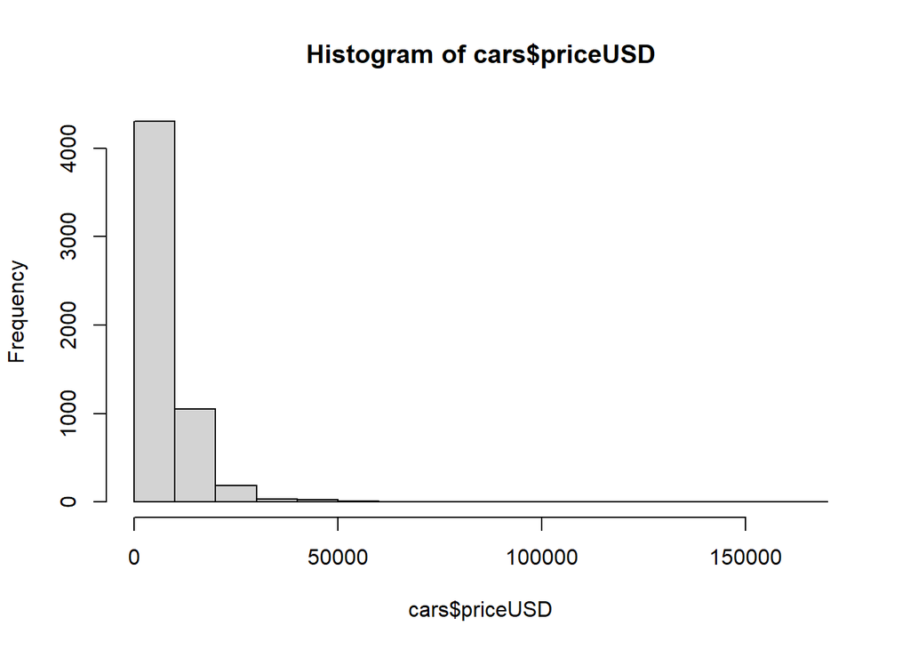

```r
hist(cars$priceUSD)
```

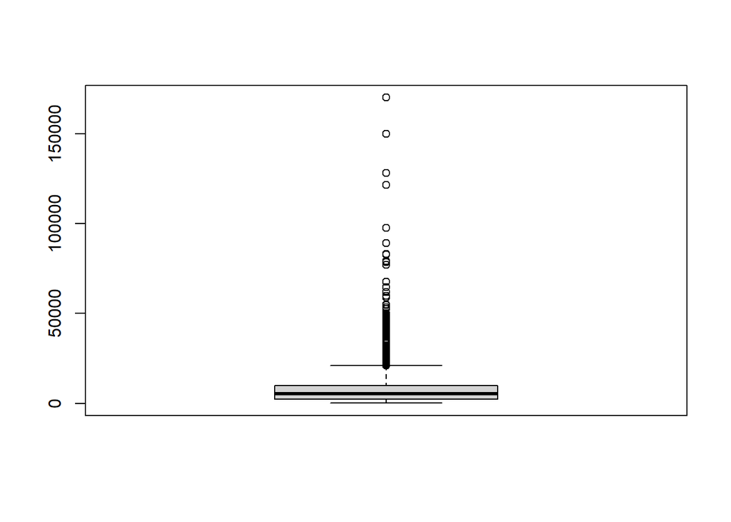

```r
boxplot(cars$priceUSD)
```

Data heavily skewed, many outliers. Let’s see the 15 most expensive cars to see, whether this variable is trustworthy:

```r
cars %>%
  arrange(desc(priceUSD)) %>%
  slice(1:15)
```

```
##             make             model priceUSD year    condition
## 1        porsche           cayenne   170000 2018 with mileage
## 2  mercedes-benz           g-klass   150000 2001 with mileage
## 3            bmw                m5   128136 2019 with mileage
## 4        mclaren           mp4-12c   121500 2013 with mileage
## 5          volvo              xc90    97512 2019 with mileage
## 6            bmw               x6m    89000 2017 with mileage
## 7  mercedes-benz           s-klass    83000 2017 with mileage
## 8            bmw                x5    82800 2019 with mileage
## 9  mercedes-benz     gle-coupe-amg    79000 2018 with mileage
## 10           bmw          6-seriya    78649 2019 with mileage
## 11       porsche            cayman    77000 2019 with mileage
## 12    land-rover range-rover-velar    67500 2018 with mileage
## 13 mercedes-benz               gls    64625 2017 with mileage
## 14           bmw          5-seriya    61796 2019 with mileage
```

[output cut: 33 more lines]

Apart from 18-year Mercedes with 160.000 km mileage the records are trustworthy: the brands are well-known for their high prices and the cars are mostly not older than 2 years.

```r
cars <- cars[cars$priceUSD != 150000, ]
```

Let’s check also logarithm form of it:

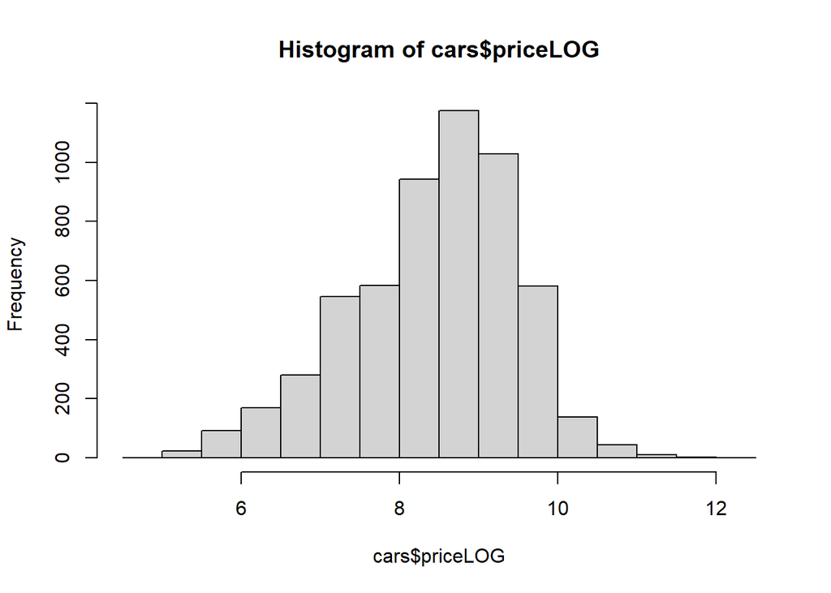

```r
cars$priceLOG <- log(cars$priceUSD)
hist(cars$priceLOG)
```

The logarithm form of dependent variable is much more symmetric than the basic forms. Therefore for the further analysis it will be used as a DEPENDENT VARIABLE.

And now I will inspect all explanatory variables one-by-one.

I will start with engine volume [cm3], as it must be cleaned up using original values of other independent variables.

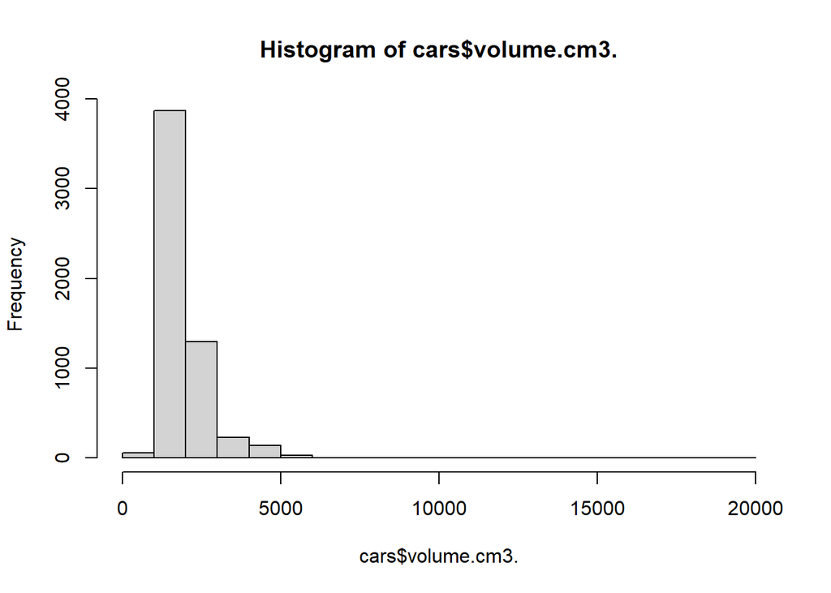

```r
hist(cars$volume.cm3.)
```

Data heavily skewed, very dubious vales. Let’s inspect the most awkward ones:

```r
cars %>%
  arrange(desc(volume.cm3.)) %>%
  slice(1:10)
```

```
##          make            model priceUSD year    condition mileage.kilometers.
## 1    lada-vaz             2101      150 1980 with mileage              300000
## 2      toyota          avensis     4000 2002 with mileage              324000
## 3     renault           trafic     7950 2004 with mileage              298670
## 4     renault           laguna     1100 1994 with mileage              300000
## 5        ford           mondeo     1500 1995 with mileage              209000
## 6     citroen c4-grand-picasso    14000 2015 with mileage              150000
## 7       rover              200      808 1995 with mileage              300000
## 8       mazda              323     1500 1997 with mileage              305000
## 9    lada-vaz             2106     1236 1987 with mileage              100000
## 10 eksklyuziv voennaya-tehnika     2500 1980 with mileage                  60
##    fuel_type volume.cm3.  color transmission                 drive_unit segment
## 1     petrol       20000 yellow    mechanics                 rear drive       B
## 2     diesel       20000  green    mechanics          front-wheel drive       D
## 3     diesel       19000   blue    mechanics          front-wheel drive       M
```

[output cut: 18 more lines]

These are mostly very known models, so I will correct those records by putting mean engine volumes from other cars of this model.

```r
cars$volume.cm3.[cars$make == "rover" & cars$model == 200 & cars$volume.cm3. == 14000  ]  <- mean(cars$volume.cm3.[cars$make == "rover" & cars$model == 200 & cars$volume.cm3. < 14000])

cars$volume.cm3.[cars$make == "mazda" & cars$model == 323 & cars$volume.cm3. == 13000 ]  <- mean(cars$volume.cm3.[cars$make == "mazda" & cars$model == 323 & cars$volume.cm3. < 13000] )

cars$volume.cm3.[cars$make == "lada-vaz" & cars$model == 2101 & cars$volume.cm3. == 20000]  <- mean(cars$volume.cm3.[cars$make == "lada-vaz" & cars$model == 2101 & cars$volume.cm3. < 20000] )

cars$volume.cm3.[cars$make == "lada-vaz" & cars$model == 2106 & cars$volume.cm3. == 13000]  <- mean(cars$volume.cm3.[cars$make == "lada-vaz" & cars$model == 2106 & cars$volume.cm3. < 13000] )

cars$volume.cm3.[cars$make == "toyota" & cars$model == 'avensis' & cars$volume.cm3. == 20000]  <- mean(cars$volume.cm3.[cars$make == "toyota" & cars$model == 'avensis' & cars$volume.cm3. < 20000] )

cars$volume.cm3.[cars$make == "citroen" & cars$model == 'c4-grand-picasso' & cars$volume.cm3. == 16000]  <- mean(cars$volume.cm3.[cars$make == "citroen" & cars$model == 'c4-grand-picasso' & cars$volume.cm3. < 16000] )

cars$volume.cm3.[cars$make == "renault" & cars$model == 'laguna' & cars$volume.cm3. == 18000]  <- mean(cars$volume.cm3.[cars$make == "renault" & cars$model == 'laguna' & cars$volume.cm3. < 18000] )

cars$volume.cm3.[cars$make == "ford" & cars$model == 'mondeo' & cars$volume.cm3. == 18000]  <- mean(cars$volume.cm3.[cars$make == "ford" & cars$model == 'mondeo' & cars$volume.cm3. < 18000] )

cars$volume.cm3.[cars$make == "renault" & cars$model == 'trafic' & cars$volume.cm3. == 19000]  <- mean(cars$volume.cm3.[cars$make == "renault" & cars$model == 'trafic' & cars$volume.cm3. < 19000] )
```

… and let last one weirdo ( eksklyuziv voennaya-tehnika) go, bye bye:

```r
cars <- cars[cars$volume.cm3. < 8000, ]
```

The following records with high engine volume have been checked on oto-moto.pl web portal to prove its correctness. Let’s see the distribution now:

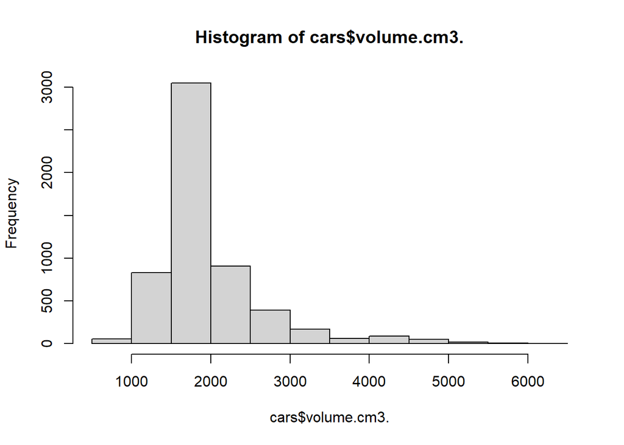

```r
hist(cars$volume.cm3.)
```

Much much better.

Car brands:

```r
table(cars$make)
```

```
##
##         acura    alfa-romeo          audi           bmw         buick
##             9            22           433           402             3
##      cadillac       changan         chery     chevrolet      chrysler
##             2             1             9            51            46
##       citroen         dacia        daewoo      daihatsu        datsun
##           194             8            34             4             3
##    eksklyuziv           faw          fiat          ford           gaz
##             7             1           101           300            19
##         geely           gmc    great-wall         haval         honda
##             8             3             7             2            92
##       hyundai      infiniti   iran-khodro         isuzu           izh
##           126            15             2             4             1
##        jaguar          jeep           kia      lada-vaz        lancia
##             7            30           104           103            16
##    land-rover         lexus         lifan       lincoln          luaz
##            40            28             8             5             1
##         mazda       mclaren mercedes-benz            mg          mini
##           174             1           360             1            11
##    mitsubishi      moskvich        nissan          opel       peugeot
##           137             7           222           372           303
##      plymouth       pontiac       porsche        proton         ravon
##             2             2            15             5             2
##       renault         rover          saab        saturn         scion
##           384            32            10             2             1
##          seat         skoda         smart     ssangyong        subaru
##            46           122             4            14            41
##        suzuki        toyota           uaz    volkswagen         volvo
##            39           229            18           674           130
##      wartburg           zaz
##             1             6
```

```r
length(table(cars$make))
```

```
## [1] 72
```

I will bin cars with respect to countries or parts of the world.

```r
cars$make[cars$make %in% c('audi', 'bmw', 'volkswagen', 'porsche', 'mercedes-benz', 'opel', 'smart')] <- "german"

cars$make[cars$make %in% c('citroen', 'peugeot', 'renault', 'alfa-romeo', 'dacia', 'fiat', 'jaguar', 'seat', 'lancia', 'land-rover', 'volvo', 'rover', 'saab', 'mini')] <- "west-european"

cars$make[cars$make %in% c('ford', 'cadillac', 'jeep', 'buick', 'gmc', 'chevrolet', 'lincoln', 'chrysler' )] <- "american"

cars$make[cars$make %in% c('honda', 'toyota', 'isuzu', 'mazda', 'mitsubishi', 'nissan' , 'subaru' , 'suzuki', 'kia', 'hyundai', 'daewoo', 'ssangyong', 'proton' , 'daihatsu', 'infiniti', 'lexus' , 'acura', 'datsun')] <- "japan/korean"

cars$make[(cars$make != "german"& cars$make != "west-european"   & cars$make != "american" & cars$make != "japan/korean" )] <- "other"

cars$make <- as.factor(cars$make)
table(cars$make)
```

```
##
##      american        german  japan/korean         other west-european
##           440          2260          1280           334          1304
```

Let’s see what is behind “model” variable

```r
unique(cars$model)
```

```
##   [1] "2"                    "3"                    "5"
##   [4] "6"                    "19"                   "21"
##   [7] "24"                   "25"                   "31"
##  [10] "45"                   "69"                   "75"
##  [13] "80"                   "100"                  "106"
##  [16] "107"                  "145"                  "146"
##  [19] "156"                  "164"                  "166"
##  [22] "200"                  "205"                  "206"
##  [25] "207"                  "208"                  "301"
##  [28] "306"                  "307"                  "308"
##  [31] "309"                  "323"                  "353"
##  [34] "400"                  "405"                  "406"
##  [37] "407"                  "408"                  "423"
##  [40] "440"                  "452"                  "460"
##  [43] "469"                  "500"                  "508"
```

[output cut: 200 more lines]

```r
length(unique(cars$model))
```

```
## [1] 644
```

644 different models - binning those cars would be long, tough and give poor results, especially when I am not that good at comparing different cars. I will delete this column without any regrets, bye bye:

```r
cars$model <- NULL
```

The dataset was collected in 2019, therefore I will change “year” variable into years to make it more comprehensible:

```r
cars$year <- 2019 - cars$year
```

…and let’s check the distribution:

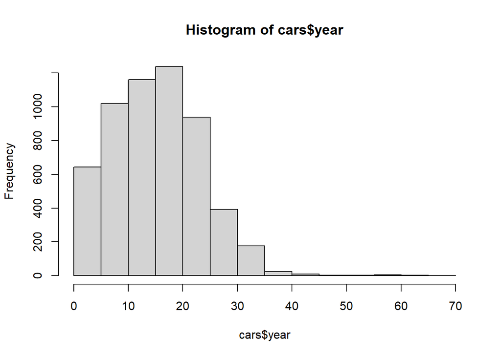

```r
hist(cars$year)
```

```r
length(cars[cars$year <36,])
```

```
## [1] 12
```

I will delete those older than 35 years, there are not many of them:

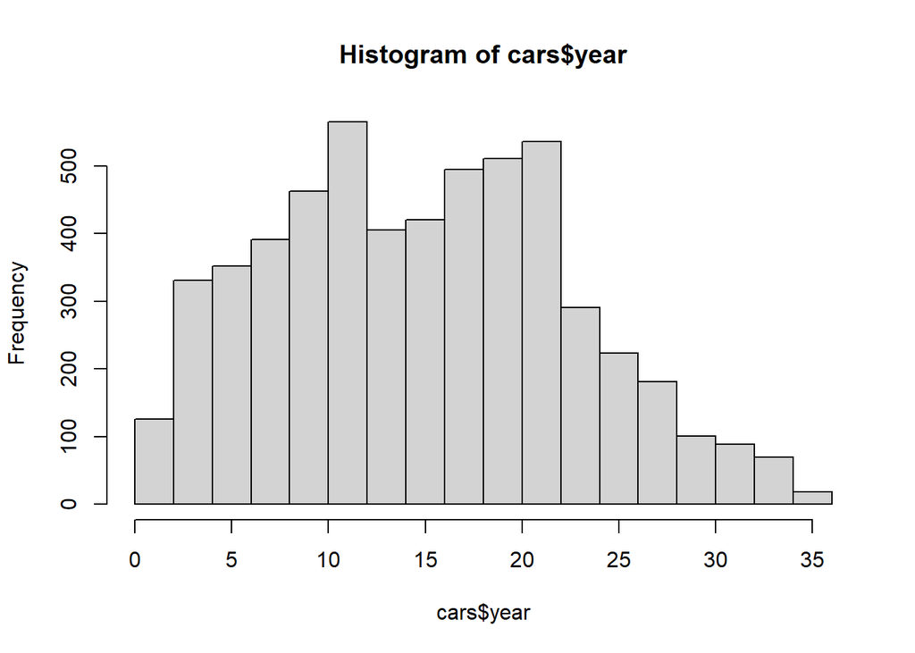

```r
cars <- cars[cars$year <36,]
hist(cars$year)
```

!!!! Because the model will be trained on records representing cars newer than 35 years, it will be valid for predictions ONLY on similar cases!!!

```r
table(cars$condition)
```

```
##
##    for parts  with damage with mileage
##           45           49         5476
```

Unfortunately, I don’t know, what this variable means. Moreover, one of its level covers more than 98% cases (near-zero variance). It must be removed:

```r
cars$condition <- NULL
```

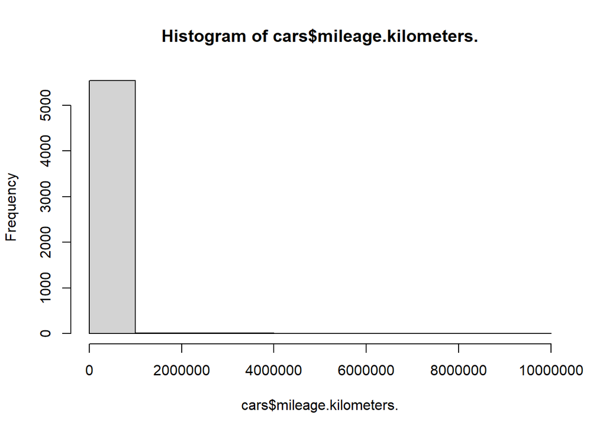

```r
options(scipen=999)
hist(cars$mileage.kilometers.)
```

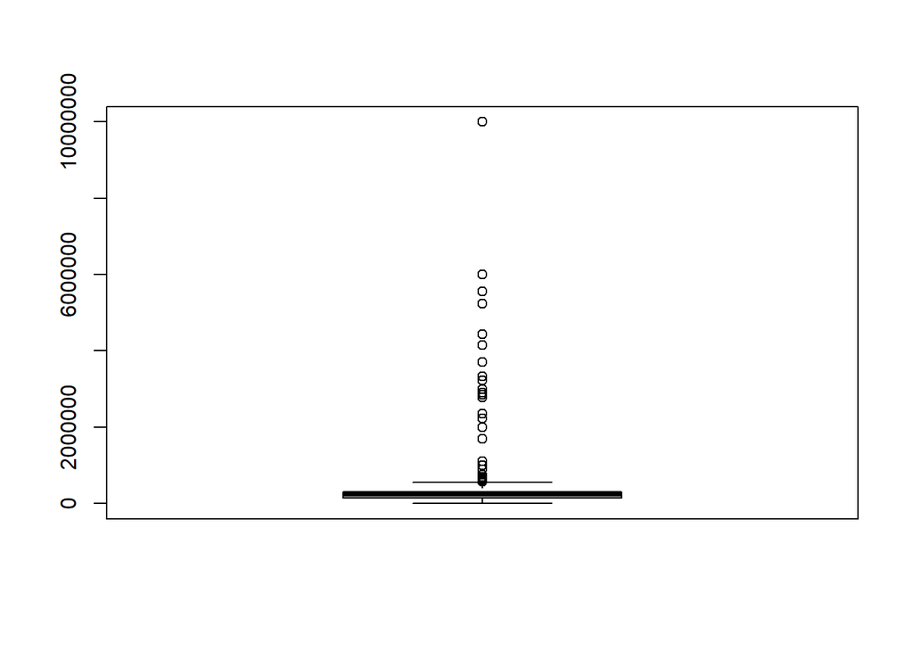

```r
boxplot(cars$mileage.kilometers.)
```

A lot of horrible outliers let’s check it:

```r
tail(sort(cars$mileage.kilometers.),50)
```

```
##  [1]  670000  675467  694000  700000  700000  700000  750000  885321  999999
## [10]  999999  999999  999999 1000000 1100000 1111111 1111111 1111111 1111111
## [19] 1111111 1111111 1111111 1111112 1686888 2000000 2222222 2222222 2222222
## [28] 2233333 2350000 2776685 2780000 2850000 2900000 3000000 3000000 3222564
## [37] 3333333 3333333 3333333 3333333 3333333 3333333 3333333 3700000 4157000
## [46] 4444444 5231758 5555555 6000000 9999999
```

```r
cars %>%
  arrange(desc(mileage.kilometers.)) %>%
  slice(1:70)
```

```
##             make priceUSD year mileage.kilometers. fuel_type volume.cm3.
## 1   japan/korean      550   33             9999999    diesel        2800
## 2         german     1300   27             6000000    diesel        1900
## 3         german     3900   27             5555555    diesel        1900
## 4         german      500   34             5231758    petrol        1800
## 5         german      950   28             4444444    diesel        1600
## 6         german     2600   26             4157000    petrol        2000
## 7       american     1650   19             3700000    diesel        1753
## 8          other      400   31             3333333    petrol        1500
## 9  west-european     4000   17             3333333    petrol        2000
## 10        german      900   28             3333333    petrol        1800
## 11 west-european     4100   22             3333333    diesel        2500
## 12        german     4500   21             3333333    diesel        1900
## 13        german     6450   12             3333333    diesel        1900
## 14        german     4400   17             3333333    diesel        2000
```

[output cut: 127 more lines]

So many horrible outliers. Moroever values like “9999999” like as if someone randomly put it into dataframe. As there are not much of them, I will delete them as well:

```r
cars <- cars[cars$mileage.kilometers. < 999999,]
```

The following high values seem to be OK - the cars are older than 12 years and don’t cost much.

Now the other way round: there are so many cars with a very low mileage:

```r
head(sort(cars$mileage.kilometers.),150)
```

```
##   [1]   0.00000   0.00000   0.00000   0.00000   0.00000   0.00000   0.00000
##   [8]   0.00000   0.00000   0.00000   0.00000   0.00000   0.00000   0.00000
##  [15]   0.00000   0.00000   1.00000   1.00000   1.00000   1.00000   1.00000
##  [22]   1.00000   1.00000   1.00000   1.00000   1.00000   1.00000   1.00000
##  [29]   1.00000   1.00000   1.00000   1.00000   1.00000   1.00000   1.00000
##  [36]   1.00000   2.00000   3.00000   3.00000   3.00000   4.00000   4.00000
##  [43]   5.00000   5.00000   5.00000  10.00000  10.00000  11.00000  11.00000
##  [50]  11.00000  13.00000  13.00000  20.00000  30.00000  30.00000  50.00000
##  [57]  67.59228  70.00000  90.00000 100.00000 100.00000 100.00000 100.00000
##  [64] 100.00000 101.00000 102.00000 108.00000 111.00000 111.00000 111.00000
##  [71] 111.00000 115.00000 118.00000 119.09116 120.00000 125.00000 134.00000
##  [78] 150.00000 150.00000 150.00000 156.00000 156.00000 160.00000 162.54334
##  [85] 170.00000 175.00000 180.00000 186.00000 190.00000 193.00000 195.00000
##  [92] 200.00000 200.00000 200.00000 200.00000 200.00000 200.00000 200.00000
##  [99] 203.00000 206.00000 209.00000 210.00000 215.00000 217.00000 220.00000
## [106] 220.00000 220.00000 222.00000 224.00000 230.00000 230.00000 232.00000
## [113] 232.00000 233.00000 237.00000 240.00000 240.00000 240.00000 240.00000
## [120] 245.00000 245.00000 245.00000 249.00000 250.00000 250.00000 250.00000
## [127] 250.00000 250.00000 250.00000 250.00000 254.27572 259.00000 260.00000
## [134] 260.00000 260.00000 260.00000 260.00000 262.00000 263.93176 264.00000
## [141] 270.00000 270.00000 273.58780 275.00000 280.00000 280.00000 280.00000
## [148] 280.00000 280.00000 280.00000
```

Maybe they are new? Let’s inspect those with mileage below 5000 km with respect to its age:

```r
length(cars$mileage.kilometers.[cars$mileage.kilometers. < 5000])
```

```
## [1] 293
```

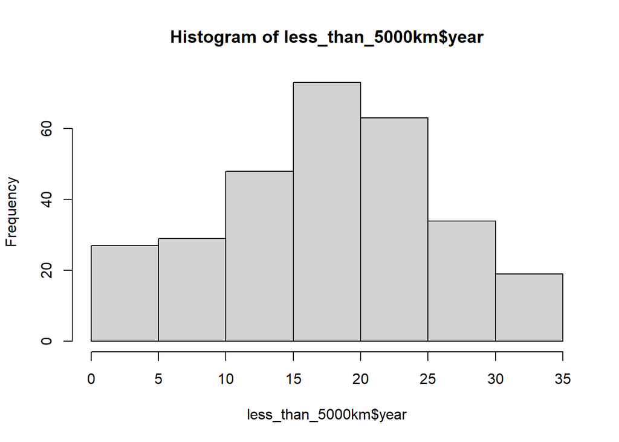

```r
less_than_5000km <- cars[cars$mileage.kilometers. < 5000 ,]

hist(less_than_5000km$year)
```

It is very doubtful, how so old cars may have so low mileage. I will delete them those records, where mileage is below 5000 km and it is older than 3 years:

```r
rm(less_than_5000km)

cars <- cars[((cars$mileage.kilometers. < 5000 & cars$year < 3) | cars$mileage.kilometers. >= 5000 )  ,]
```

```r
table(cars$color)
```

```
##
##    black     blue    brown burgundy     gray    green   orange    other
##     1141      761      142      191      537      367       20      336
##   purple      red   silver    white   yellow
##       56      244      949      482       30
```

The column has a lot of levels. Such a variable in case of this dataset is also not very valuable one. Therefore I will delete this variable:

```r
cars$color <- NULL
```

```r
table(cars$segment)
```

```
##
##         A    B    C    D    E    F    J    M    S
##  477   36  407 1014 1153  581   87  835  582   84
```

As it was written in the description of the dates on Kaggle, the choice of segment for each of the car was chosen arbitrarily, i.e. it has not been proved with official cars classification regarding its segment. So, even if it would be a precious variable, I cannot rely on it, therefore it will be removed:

```r
cars$segment <- NULL
```

Now time for binary variables, these ones must be also turned into factors:

```r
table(cars$fuel_type)
```

```
##
## diesel petrol
##   1867   3389
```

```r
cars$fuel_type <- as.factor(cars$fuel_type)
```

```r
table(cars$transmission)
```

```
##
##      auto mechanics
##      1915      3341
```

```r
cars$transmission <- as.factor(cars$transmission)
```

```r
table(cars$drive_unit)
```

```
##
##                                       all-wheel drive
##                        178                        578
##          front-wheel drive part-time four-wheel drive
##                       3543                        332
##                 rear drive
##                        625
```

```r
#turn NAs into "Unknown"

cars$drive_unit[which(cars$drive_unit == "") ] <- "Unknown"
cars$drive_unit <- as.factor(cars$drive_unit)
```

Let’s check correlations:

```r
cars_correlations <-
  cor(cars[,c('priceUSD', 'year', 'mileage.kilometers.', 'volume.cm3.')],
      use = "pairwise.complete.obs")

cars_correlations
```

```
##                       priceUSD        year mileage.kilometers. volume.cm3.
## priceUSD             1.0000000 -0.63294193         -0.41724167  0.34918665
## year                -0.6329419  1.00000000          0.58420373 -0.04640571
## mileage.kilometers. -0.4172417  0.58420373          1.00000000  0.06974505
## volume.cm3.          0.3491867 -0.04640571          0.06974505  1.00000000
```

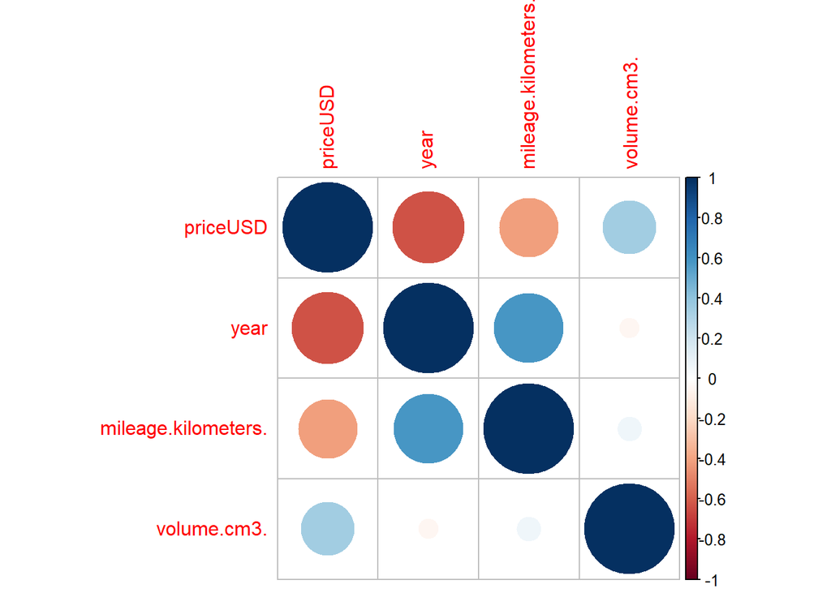

```r
library(corrplot)

corrplot(cars_correlations)
```

The strength and sign of correlation is the same as we may suppose. Variables “year” and “mileage.kilometers” are strongly correlated - it will be a problem while modelling, but I will not spoil now.

## Creating test and train dataset

```r
set.seed(987654321)
which_train <- createDataPartition(y = cars$priceUSD,
                                   p = 0.7,
                                   list = FALSE)

cars_train <- cars[which_train,]
cars_test <- cars[-which_train,]
```

… and preparing model formula.

As mentioned above: because the log form of DepVar is almost symmetric one, I will stick to it in further analysis.s

```r
variables <- names(cars_train)
model.formula <- as.formula(paste("priceLOG ~",
                                  paste(variables[!variables %in% c("priceUSD", "priceLOG" )],
                                        collapse = " + ")))
model.formula
```

```
## priceLOG ~ make + year + mileage.kilometers. + fuel_type + volume.cm3. +
##     transmission + drive_unit
```

### LINEAR REGRESSION

The most simple model will serve as a benchmark:

```r
linear_regression1 <- lm(model.formula, data = cars_train)
summary(linear_regression1)
```

```
##
## Call:
## lm(formula = model.formula, data = cars_train)
##
## Residuals:
##     Min      1Q  Median      3Q     Max
## -3.1938 -0.1893  0.0283  0.2339  2.9935
##
## Coefficients:
##                                            Estimate     Std. Error t value
## (Intercept)                           9.61267839989  0.05275488342 182.214
## makegerman                            0.41558522851  0.02814956058  14.763
## makejapan/korean                      0.19591309567  0.02942212016   6.659
## makeother                            -0.08518461773  0.03987785162  -2.136
## makewest-european                     0.12051000762  0.02932919487   4.109
## year                                 -0.10643823755  0.00128367203 -82.917
## mileage.kilometers.                   0.00000002640  0.00000008226   0.321
## fuel_typepetrol                      -0.20014286125  0.01618276111 -12.368
## volume.cm3.                           0.00028320874  0.00001295841  21.855
## transmissionmechanics                -0.11432502414  0.01905454682  -6.000
## drive_unitfront-wheel drive          -0.20848104955  0.02745739466  -7.593
## drive_unitpart-time four-wheel drive  0.02858459270  0.03592291131   0.796
## drive_unitrear drive                 -0.11738580356  0.03095891657  -3.792
## drive_unitUnknown                    -0.23481571640  0.04653645262  -5.046
##                                                  Pr(>|t|)
## (Intercept)                          < 0.0000000000000002 ***
## makegerman                           < 0.0000000000000002 ***
## makejapan/korean                       0.0000000000317426 ***
## makeother                                        0.032734 *
## makewest-european                      0.0000406281470969 ***
## year                                 < 0.0000000000000002 ***
## mileage.kilometers.                              0.748282
## fuel_typepetrol                      < 0.0000000000000002 ***
## volume.cm3.                          < 0.0000000000000002 ***
## transmissionmechanics                  0.0000000021662053 ***
## drive_unitfront-wheel drive            0.0000000000000395 ***
## drive_unitpart-time four-wheel drive             0.426246
## drive_unitrear drive                             0.000152 ***
## drive_unitUnknown                      0.0000004734386576 ***
## ---
## Signif. codes:  0 '***' 0.001 '**' 0.01 '*' 0.05 '.' 0.1 ' ' 1
##
## Residual standard error: 0.4218 on 3667 degrees of freedom
## Multiple R-squared:  0.8316, Adjusted R-squared:  0.831
## F-statistic:  1393 on 13 and 3667 DF,  p-value: < 0.00000000000000022
```

As it was hinted above, because of a strong correlation between year and mileage variables, the model treats the latter as highly insignificant. Let’s see how the model changes, if we introduce a synthetic variable derived by division of mileage by year and exclude the original ones (@MR SAKOWSKI: THANKS FOR SUGGESTION DURING PRESENTATION!!!) :

```r
cars_train$mileage_by_year <- ifelse(cars_train$year != 0, cars_train$mileage.kilometers. / cars_train$year, 0)

variables2 <- colnames(cars_train)

model.formula2 <- as.formula(paste("priceLOG ~",
                                  paste(variables2[!variables %in% c("priceUSD", "priceLOG" , "year", "mileage.kilometers.")],
                                        collapse = " + ")))
model.formula2
```

```
## priceLOG ~ make + fuel_type + volume.cm3. + transmission + drive_unit +
##     mileage_by_year
```

```r
linear_regression2 <- lm(model.formula2, data = cars_train)
summary(linear_regression2)
```

```
##
## Call:
## lm(formula = model.formula2, data = cars_train)
##
## Residuals:
##     Min      1Q  Median      3Q     Max
## -2.8128 -0.4396  0.0288  0.5086  3.3560
##
## Coefficients:
##                                          Estimate   Std. Error t value
## (Intercept)                           8.512286743  0.101085614  84.209
## makegerman                            0.227955800  0.049400198   4.614
## makejapan/korean                      0.166914433  0.051856389   3.219
## makeother                             0.156454402  0.069917266   2.238
## makewest-european                     0.058475482  0.051641685   1.132
## fuel_typepetrol                      -0.172357019  0.028425560  -6.063
## volume.cm3.                           0.000087284  0.000022286   3.917
## transmissionmechanics                -0.774361504  0.030825542 -25.121
## drive_unitfront-wheel drive          -0.552275288  0.047783751 -11.558
## drive_unitpart-time four-wheel drive  0.004033689  0.063300152   0.064
## drive_unitrear drive                 -0.667004863  0.053481473 -12.472
## drive_unitUnknown                    -0.702870132  0.081404029  -8.634
## mileage_by_year                       0.000039037  0.000001488  26.228
##                                                  Pr(>|t|)
## (Intercept)                          < 0.0000000000000002 ***
## makegerman                                  0.00000407575 ***
## makejapan/korean                                   0.0013 **
## makeother                                          0.0253 *
## makewest-european                                  0.2576
## fuel_typepetrol                             0.00000000147 ***
## volume.cm3.                                 0.00009145855 ***
## transmissionmechanics                < 0.0000000000000002 ***
## drive_unitfront-wheel drive          < 0.0000000000000002 ***
## drive_unitpart-time four-wheel drive               0.9492
## drive_unitrear drive                 < 0.0000000000000002 ***
## drive_unitUnknown                    < 0.0000000000000002 ***
## mileage_by_year                      < 0.0000000000000002 ***
## ---
## Signif. codes:  0 '***' 0.001 '**' 0.01 '*' 0.05 '.' 0.1 ' ' 1
##
## Residual standard error: 0.7434 on 3668 degrees of freedom
## Multiple R-squared:  0.4768, Adjusted R-squared:  0.475
## F-statistic: 278.5 on 12 and 3668 DF,  p-value: < 0.00000000000000022
```

Judging by adjusted R2 measure it was not a good idea. Let’s remove the new variable:

```r
cars_train$mileage_by_year <- NULL
```

So let’s just remove variable “mileage” and leave “year” as common indicator of how the cars are exploited.

```r
model.formula3 <- as.formula(paste("priceLOG ~",
                                  paste(variables[!variables %in% c("priceUSD", "priceLOG" , "mileage.kilometers.")],
                                        collapse = " + ")))
model.formula3
```

```
## priceLOG ~ make + year + fuel_type + volume.cm3. + transmission +
##     drive_unit
```

```r
linear_regression3 <- lm(model.formula3, data = cars_train)
summary(linear_regression3)
```

```
##
## Call:
## lm(formula = model.formula3, data = cars_train)
##
## Residuals:
##     Min      1Q  Median      3Q     Max
## -3.1859 -0.1898  0.0281  0.2348  2.9897
##
## Coefficients:
##                                         Estimate  Std. Error t value
## (Intercept)                           9.61423991  0.05252360 183.046
## makegerman                            0.41613004  0.02809489  14.812
## makejapan/korean                      0.19610776  0.02941227   6.668
## makeother                            -0.08627592  0.03972775  -2.172
## makewest-european                     0.12085058  0.02930641   4.124
## year                                 -0.10621041  0.00106938 -99.319
## fuel_typepetrol                      -0.20186883  0.01526112 -13.228
## volume.cm3.                           0.00028377  0.00001284  22.104
## transmissionmechanics                -0.11404311  0.01903196  -5.992
## drive_unitfront-wheel drive          -0.20747952  0.02727614  -7.607
## drive_unitpart-time four-wheel drive  0.02876250  0.03591424   0.801
## drive_unitrear drive                 -0.11670965  0.03088337  -3.779
## drive_unitUnknown                    -0.23397551  0.04645707  -5.036
##                                                  Pr(>|t|)
## (Intercept)                          < 0.0000000000000002 ***
## makegerman                           < 0.0000000000000002 ***
## makejapan/korean                       0.0000000000299075 ***
## makeother                                         0.02994 *
## makewest-european                      0.0000381109319305 ***
## year                                 < 0.0000000000000002 ***
## fuel_typepetrol                      < 0.0000000000000002 ***
## volume.cm3.                          < 0.0000000000000002 ***
## transmissionmechanics                  0.0000000022701238 ***
## drive_unitfront-wheel drive            0.0000000000000355 ***
## drive_unitpart-time four-wheel drive              0.42326
## drive_unitrear drive                              0.00016 ***
## drive_unitUnknown                      0.0000004972675212 ***
## ---
## Signif. codes:  0 '***' 0.001 '**' 0.01 '*' 0.05 '.' 0.1 ' ' 1
##
## Residual standard error: 0.4218 on 3668 degrees of freedom
## Multiple R-squared:  0.8316, Adjusted R-squared:  0.831
## F-statistic:  1509 on 12 and 3668 DF,  p-value: < 0.00000000000000022
```

Let’s also compare all 3 models above using AIC criterion as it is a good method to compare predictive models with different number of predictors:

```r
AIC(linear_regression1)
```

```
## [1] 4107.973
```

```r
AIC(linear_regression2)
```

```
## [1] 8278.658
```

```r
AIC(linear_regression3)
```

```
## [1] 4106.077
```

The 3rd model without “mileage” variable did not improve much compared to the 1st one with full set of independent variables, nevertheless leaving redundant variables makes the model simpler and therefore less vulnerable to overfitting.

```r
rm(linear_regression1)
rm(linear_regression2)
```

Saving predictions:

```r
pred_lm_train <- predict(linear_regression3, newdata = cars_train)
measures_lm_train <- getRegressionMetrics(real = cars_train$priceLOG,
                     predicted = pred_lm_train)


pred_lm_test <- predict(linear_regression3, newdata = cars_test)
measures_lm_test <- getRegressionMetrics(real = cars_test$priceLOG,
                     predicted = pred_lm_test)
```

### REGRESSION TREE

The advantage of regression tree its non-sensitiveness to outliers and easiness to interpret and visualize.

Out of all 3 functions to create the decision trees (train, tree, rpart) showed during lectures, the best performance on the test data gives the rpart function. Not to bore my reader, I won’t include those other ones here.

To tune the parameters I used the same functions as it was used during labs.

```r
hyper_grid <- expand.grid(
  minsplit = seq(5, 20, 1),
  maxdepth = seq(8, 15, 1)
)



models <- list()
for (i in 1:nrow(hyper_grid)) {



  # setting the values
  minsplit <- hyper_grid$minsplit[i]
  maxdepth <- hyper_grid$maxdepth[i]

  # settin the seed
  set.seed(123123 + i)

  # training of the model and saving results to the list
  models[[i]] <- rpart(
    formula = model.formula ,
    data    = cars_train,
    method  = "anova",
    control = list(minsplit = minsplit, maxdepth = maxdepth)
  )
}


get_cp <- function(x) {
  min <- which.min(x$cptable[, "xerror"])
  cp  <- x$cptable[min, "CP"]
  return(cp)
}

get_min_error <- function(x) {
  min    <- which.min(x$cptable[, "xerror"])
  xerror <- x$cptable[min, "xerror"]
  return(xerror)
}


hyper_grid %>%
  mutate(
    cp    = purrr::map_dbl(models, get_cp),
    error = purrr::map_dbl(models, get_min_error)
  ) %>%
  arrange(error) %>%
  top_n(-5, wt = error)
```

```
##   minsplit maxdepth   cp     error
## 1        8        9 0.01 0.2580689
## 2        7       11 0.01 0.2581082
## 3        5        9 0.01 0.2582267
## 4        9        9 0.01 0.2582505
## 5       19       12 0.01 0.2582529
```

Then I will insert the values of parameters which obtained the lowest error:

```r
cars.tree <- rpart(
  formula = model.formula,
  data    = cars_train,
  method  = "anova",
  control = list(minsplit =8, maxdepth = 9, cp = 0.01)
)
```

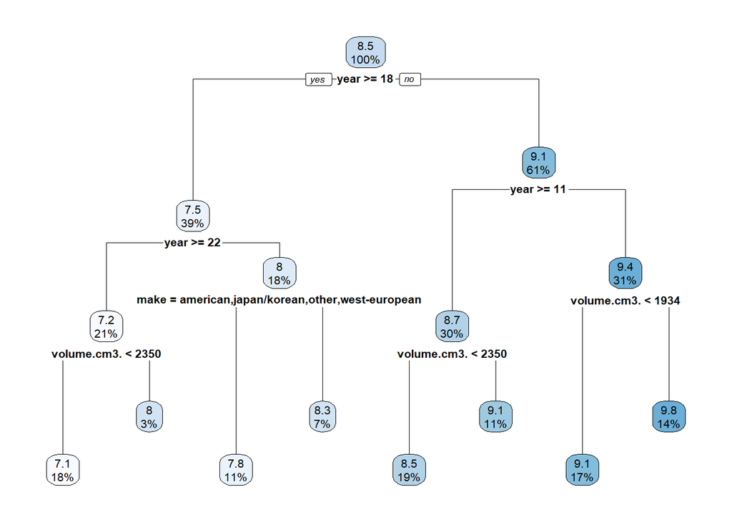

```r
rpart.plot(cars.tree)
```

Another advantage of this algorithm is to pick up the most important variables. As we can see only 3 variables were used in the final model: year, engine volume and brand.

Saving predictions:

```r
pred_tree_train <- predict(cars.tree, newdata = cars_train)
measures_tree_train <- getRegressionMetrics(real = cars_train$priceLOG,
                     predicted = pred_tree_train)


pred_tree_test <- predict(cars.tree, newdata = cars_test)
measures_tree_test <- getRegressionMetrics(real = cars_test$priceLOG,
                     predicted = pred_tree_test)
```

## RANDOM FORESTS

Random forests help to reduce tree correlation by introducing more randomness into the tree-growing process. More specifically, for every single regression tree from the forest, the trained data is bootstrapped from the original training dataset. As it was proved during labs, in a process of bootstrapping the sample, ca. 30% of the dataset is rejected. This 30% of data may be used then to prove the quality of the model, i.e out-of-bag error (“oob”)

Moreover for every single regression tree not all independent variables are used, but its subset. The number of chosen variables must be found using cross-validation. In my model I will try to check number of independent variables between 2 and 6.

Such a method is robust to correlated variables, which in my case is very precious trait - year and mileage variables are highly correlated. It has also the ability to asses the importance of variables, I am going to plot it.

THe number of decision tree in the forest and minimal node size was chosen using trial and error method.

```r
set.seed(123457)
parameters_rf <- expand.grid(mtry = 2:6)
ctrl_oob <- trainControl(method = "oob")




cars.rf <-    train(model.formula,
          data = cars_train,
          method = "rf",
          ntree = 500,
          nodesize = 350,
          tuneGrid = parameters_rf,
          trControl = ctrl_oob,
          importance = TRUE)


cars.rf
```

```
## Random Forest
##
## 3681 samples
##    7 predictor
##
## No pre-processing
## Resampling results across tuning parameters:
##
##   mtry  RMSE       Rsquared
##   2     0.5581247  0.7040581
##   3     0.5053676  0.7573620
##   4     0.4739972  0.7865503
##   5     0.4583606  0.8004009
##   6     0.4501170  0.8075160
##
## RMSE was used to select the optimal model using the smallest value.
## The final value used for the model was mtry = 6.
```

The best number of used variables is 6:

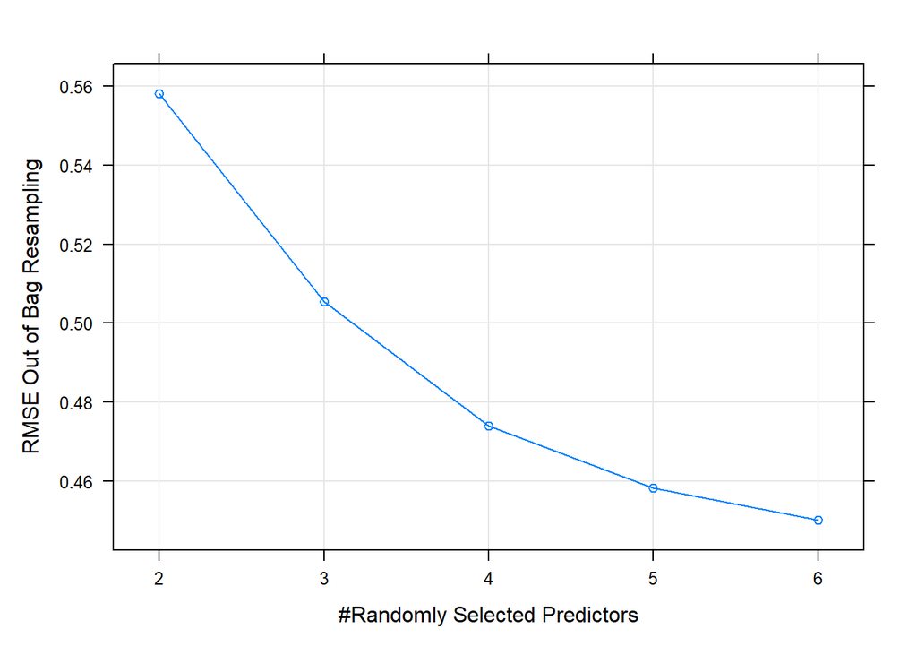

```r
plot(cars.rf)
```

… and promised variable importance:

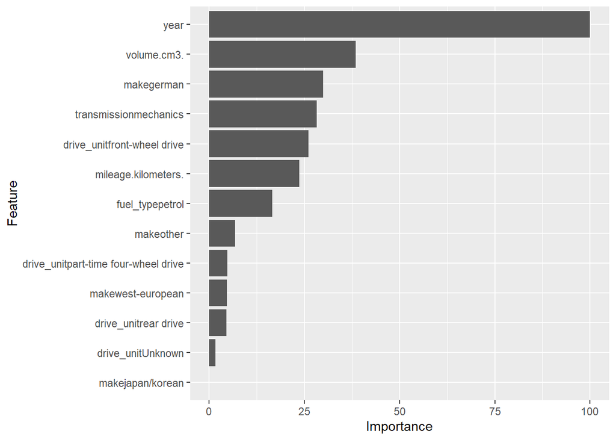

```r
var_importance_rf <- varImp(cars.rf)

## S3 method for class 'varImp.train'
ggplot(
  var_importance_rf,
  mapping = NULL,
  top = dim(var_importance_rf$importance)[1],
    environment = NULL
)
```

Let’s compare performance of the model on training and testing dataset to check if it is not overfitted:

```r
pred_rf_train <- predict(cars.rf, newdata = cars_train)
measures_rf_train <- getRegressionMetrics(real = cars_train$priceLOG,
                     predicted = pred_rf_train)


pred_rf_test <- predict(cars.rf, newdata = cars_test)
measures_rf_test <- getRegressionMetrics(real = cars_test$priceLOG,
                     predicted = pred_rf_test)
```

## Gradient boost

Gradient boost method is one of couple of models based on the idea of boosting. Boosting is an ensemble modeling technique that attempts to build a strong classifier from the number of weak classifiers, i.e. the consecutive trees are correcting the previous one.

I will use cross validation to tune 4 parameters:

1. n.trees – Number of trees (here: the number of gradient boosting iteration) i.e. N. Increasing N reduces the error on training set, but setting it too high may lead to over-fitting.
2. interaction.depth (Maximum nodes per tree) - number of splits it has to perform on a tree (starting from a single node).
3. Shrinkage (Learning Rate) – It is considered as a learning rate. Shrinkage is commonly used in ridge regression where it reduces regression coefficients to zero and, thus, reduces the impact of potentially unstable regression coefficients. In the context of GBMs, shrinkage is used for reducing, or shrinking, the impact of each additional fitted base-learner (tree).

Source: https://www.listendata.com/2015/07/gbm-boosted-models-tuning-parameters.html

```r
parameters_gbm <- expand.grid(interaction.depth = c(1, 2, 3, 4),
                             n.trees = c(300, 400),
                             shrinkage = c( 0.01,  0.05,  0.1),
                             n.minobsinnode = c( 300, 400))
ctrl_cv10 <- trainControl(method = "cv",
                         number =10)

  cars.gbm  <- train(model.formula,
                         data = cars_train,
                         distribution = "gaussian",
                         method = "gbm",
                         tuneGrid = parameters_gbm,
                         trControl = ctrl_cv10,
                         verbose = FALSE)


  cars.gbm
```

```
## Stochastic Gradient Boosting
##
## 3681 samples
##    7 predictor
##
## No pre-processing
## Resampling: Cross-Validated (10 fold)
## Summary of sample sizes: 3314, 3313, 3313, 3312, 3313, 3314, ...
## Resampling results across tuning parameters:
##
##   shrinkage  interaction.depth  n.minobsinnode  n.trees  RMSE       Rsquared
##   0.01       1                  300             300      0.5436561  0.7624546
##   0.01       1                  300             400      0.5064055  0.7841606
##   0.01       1                  400             300      0.5504793  0.7513722
##   0.01       1                  400             400      0.5173144  0.7700421
##   0.01       2                  300             300      0.4858129  0.7942743
##   0.01       2                  300             400      0.4619705  0.8053248
##   0.01       2                  400             300      0.5046391  0.7747535
##   0.01       2                  400             400      0.4833230  0.7855039
##   0.01       3                  300             300      0.4711780  0.8007038
##   0.01       3                  300             400      0.4545624  0.8080377
##   0.01       3                  400             300      0.5039640  0.7748458
##   0.01       3                  400             400      0.4827746  0.7857051
##   0.01       4                  300             300      0.4707339  0.8001592
##   0.01       4                  300             400      0.4548569  0.8074054
##   0.01       4                  400             300      0.5038641  0.7752484
##   0.01       4                  400             400      0.4825352  0.7860477
##   0.05       1                  300             300      0.4423985  0.8150516
##   0.05       1                  300             400      0.4407549  0.8165822
##   0.05       1                  400             300      0.4649106  0.7961125
##   0.05       1                  400             400      0.4638042  0.7970982
##   0.05       2                  300             300      0.4365242  0.8201525
##   0.05       2                  300             400      0.4346030  0.8217292
##   0.05       2                  400             300      0.4615299  0.7992627
##   0.05       2                  400             400      0.4593517  0.8010553
##   0.05       3                  300             300      0.4336442  0.8225522
##   0.05       3                  300             400      0.4314880  0.8244105
##   0.05       3                  400             300      0.4614651  0.7991856
##   0.05       3                  400             400      0.4594898  0.8010680
##   0.05       4                  300             300      0.4337817  0.8224250
```

[output cut: 57 more lines]

```
##   0.3045454
##   0.3293355
##   0.3277912
##   0.3041383
##   0.3027602
##   0.3294404
##   0.3277659
##   0.3025887
##   0.3016365
##   0.3286505
##   0.3267001
##
## RMSE was used to select the optimal model using the smallest value.
## The final values used for the model were n.trees = 400, interaction.depth =
##  4, shrinkage = 0.1 and n.minobsinnode = 300.
```

Let’s plot the changes relations of all tuned parameters:

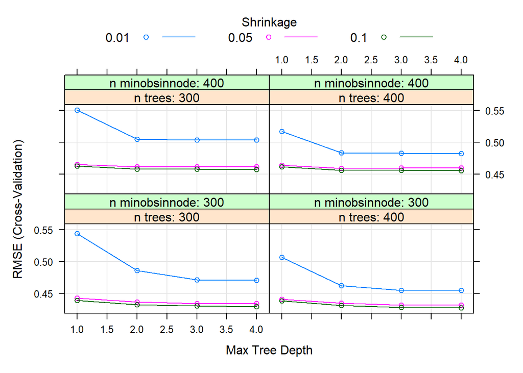

```r
plot(cars.gbm)
```

..and save predictions both on train and test dataset:

```r
pred_gbm_train <- predict(cars.gbm, newdata = cars_train)
measures_gbm_train <- getRegressionMetrics(real = cars_train$priceLOG,
                     predicted = pred_gbm_train)


pred_gbm_test <- predict(cars.gbm, newdata = cars_test)
measures_gbm_test <- getRegressionMetrics(real = cars_test$priceLOG,
                     predicted = pred_gbm_test)
```

## Comparison of models’ qualities and conclusion

Binding all data together:

```r
comparison  <- rbind(measures_lm_train, measures_lm_test, measures_tree_train, measures_tree_test, measures_rf_train, measures_rf_test, measures_gbm_train, measures_gbm_test)

comparison$method <- c('measures_lm_train', 'measures_lm_test', 'measures_tree_train', 'measures_tree_test', 'measures_rf_train', 'measures_rf_test', 'measures_gbm_train', 'measures_gbm_test')

comparison
```

```
##         MSE      RMSE       MAE     MedAE        MSLE        R2
## 1 0.1772835 0.4210505 0.2974200 0.2150079 0.002397606 0.8315728
## 2 0.1667757 0.4083818 0.2986661 0.2198196 0.002245581 0.8456977
## 3 0.2687770 0.5184371 0.3837582 0.2976962 0.003470098 0.7446498
## 4 0.2716034 0.5211558 0.3908512 0.3045188 0.003535867 0.7487103
## 5 0.1943709 0.4408752 0.3128292 0.2247194 0.002607722 0.8153389
## 6 0.2056299 0.4534643 0.3281406 0.2334157 0.002791572 0.8097495
## 7 0.1637757 0.4046921 0.2829799 0.1945873 0.002205673 0.8444058
## 8 0.1666052 0.4081731 0.2917762 0.2074028 0.002274597 0.8458555
##                method
## 1   measures_lm_train
## 2    measures_lm_test
## 3 measures_tree_train
## 4  measures_tree_test
## 5   measures_rf_train
## 6    measures_rf_test
## 7  measures_gbm_train
## 8   measures_gbm_test
```

As the tree-based models are prone to be overfitted, I measured performance also on the training dataset to see, if the performances on both subsets are similar. We may see, that the random forest model performed slightly better on the train dataset.